# RUV_FF_vs_Mal_all_groups_Salmon

Raquel Pinho

6 de maio de 2019

# 1 Data

This code was writen using data from mhlz experiment 2016, where Malnourished and full fed animals were compared after the ingestion of regular milk, lysozyme-rich milk or no milk. The expression along the length of the intestinal tract were assessed by underlying distribution of RNA-seq data. In total we have seven groups and 4 or three animals per group.

I will first set the working directory to where output are going to be saved and choose the groups to be compared if it was not defined on the command line in the server, besides setting up the knitr options:

```r
#args = commandArgs(trailingOnly=TRUE)
setwd("C:/Users/rpmello/Desktop/Data Analysis RNASeq/Projeto_Salmon_DESeq_EdgeR")
dir.create(file.path("C:/Users/rpmello/Desktop/Data Analysis RNASeq/Projeto_Salmon_DESeq_EdgeR/Output", sprintf("FF_vs_Mal_all_groups_Salmon_R_with_outliers")), showWarnings = FALSE)
output_dir<-file.path("C:/Users/rpmello/Desktop/Data Analysis RNASeq/Projeto_Salmon_DESeq_EdgeR/Output", sprintf("FF_vs_Mal_all_groups_Salmon_R_with_outliers"))
dir.create(file.path(output_dir, "Figures"), showWarnings = FALSE)
print("Comparison between FF and Mal independently of milk all sections together.")
```

```
## [1] "Comparison between FF and Mal independently of milk all sections together."
```

```r
knitr::opts_chunk$set(echo = TRUE, results = "asis", include = TRUE, fig.path = file.path(output_dir,"Figures"), fig.width = 11, fig.height = 8, fig.show = "animated")
```

# 2 DESeq2 analysis

I will follow the DESeq2 tutorial found [here](https://github.com/mikelove/asthma) and here

And I will start creating a table of counts with all the samples.But for this I will have to import the counts data and the metadata.

## 2.1 Importing the data

The data used was the quant.sf files output from the Salmon software. And I will select the data and the metadata to the groups selected for comparison.

## 2.2 Importing and creating the metadata table

The metadata for the specified comparison was:

```r
head(selectMetadata)
```

|  | Pig | Description | SampleID | list_of_files | Index | Group | Group_sectio | Trial | Time | Section | Diet | Fed | Ecoli | SectionTimeFed | TimeSectionFedChal | TRT | Collection | RNA_ext | Lib_const | Suceptability | Lane | Weight_3Week | ..22 | RIN | Final_Weight | MLNT | mean_hist_crypt_value | mean_hist_height_value | mean_hist_LP_value | … |
| --- | --- | --- | --- | --- | --- | --- | --- | --- | --- | --- | --- | --- | --- | --- | --- | --- | --- | --- | --- | --- | --- | --- | --- | --- | --- | --- | --- | --- | --- | --- |
| FF1 | 33-12 | 33-12D | index3L2 | index3L2_salmon_trim_quant.counts | 3 | FF | FFD | mhLZ | Wk5 | Duodenum | FF | No | No | Duod_5FF | Wk5_Duod_FFNo | 5FF | 6_17A | 4 | 8_25 | NA | 2 | 9.0 | NA | 7.7 | 16.6 | 75528.7 | 401.587 | 502.540 | 561.960 | … |
| FF2 | 33-12 | 33-12I | index2L7 | index2L7_salmon_trim_quant.counts | 2 | FF | FFI | mhLZ | Wk5 | Ileum | FF | No | No | Ileum_5FF | Wk5_Il_FFNo | 5FF | 6_17A | 16 | 8_29 | NA | 7 | 9.0 | NA | 8.9 | 16.6 | 75528.7 | 248.877 | 370.518 | 249.878 | … |
| FF3 | 33-12 | 33-12J | index7L2 | index7L2_salmon_trim_quant.counts | 7 | FF | FFJ | mhLZ | Wk5 | Jejunum | FF | No | No | Jej_5FF | Wk5_Jej_FFNo | 5FF | 6_17A | 10 | 8_27 | NA | 2 | 9.0 | NA | 7.5 | 16.6 | 75528.7 | 298.013 | 539.632 | 312.566 | … |
| FF4 | 6-10 | 6-10D | index5L5 | index5L5_salmon_trim_quant.counts | 5 | FF | FFD | mhLF | Wk5 | Duodenum | FF | No | No | Duod_5FF | Wk5_Duod_FFNo | 5FF | 4_3 | 5 | 8_25 | NA | 5 | 10.5 | NA | 8.8 | 17.1 | 451500.0 | 473.050 | 418.754 | 550.390 | … |
| FF5 | 6-10 | 6-10I | index6L7 | index6L7_salmon_trim_quant.counts | 6 | FF | FFI | mhLF | Wk5 | Ileum | FF | No | No | Ileum_5FF | Wk5_Il_FFNo | 5FF | 4_3 | 17 | 8_29 | NA | 8 | 10.5 | NA | 7.9 | 17.1 | 451500.0 | 319.822 | 365.104 | 338.924 | … |
| FF6 | 6-10 | 6-10J | index1L5 | index1L5_salmon_trim_quant.counts | 1 | FF | FFJ | mhLF | Wk5 | Jejunum | FF | No | No | Jej_5FF | Wk5_Jej_FFNo | 5FF | 4_3 | 11 | 8_27 | NA | 5 | 10.5 | NA | 9.2 | 17.1 | 451500.0 | 253.839 | 561.176 | 382.522 | … |

### 2.2.1 Removing dependent variables

I will remove the metadata that does not present a variation in this comparison or have all unique values in this comparison

```r
batch_effects<-sapply(1:ncol(selectMetadata), function(i){length(unique(selectMetadata[,i]))!= 1 & length(unique(selectMetadata[,i])) != length(selectMetadata[,i])})
batch_effects<-selectMetadata[,batch_effects]
dependent<-sapply(1:ncol(batch_effects), function(i){length(unique(batch_effects[1:4,i])) == 1 & length(unique(batch_effects[5:8,i])) == 1})
independent<-which(!dependent)
batch_effects<-batch_effects[,independent]
batch_effects$Group<-selectMetadata$Group
batch_effects$Diet<-selectMetadata$Diet
batch_effects
```

|  | Pig | Index | Group_sectio | Trial | Section | SectionTimeFed | TimeSectionFedChal | Collection | RNA_ext | Lib_const | Lane | Weight_3Week | RIN | Final_Weight | MLNT | Small_weight | Small_body_ratio | Bacteriodetes | wt_lt_ratio | z_score_animal | Litter | Conductance | Paracellular_permeability | Transcellular_permeability | Group | Diet |
| --- | --- | --- | --- | --- | --- | --- | --- | --- | --- | --- | --- | --- | --- | --- | --- | --- | --- | --- | --- | --- | --- | --- | --- | --- | --- | --- |
| FF1 | 33-12 | 3 | FFD | mhLZ | Duodenum | Duod_5FF | Wk5_Duod_FFNo | 6_17A | 4 | 8_25 | 2 | 9.0 | 7.7 | 16.6 | 75528.7009 | 1542 | 92.89157 | 0.023587493 | 0.2178478 | -0.9111080 | 33 | 6.760 | 183.2455 | -2.421892 | FF | FF |
| FF2 | 33-12 | 2 | FFI | mhLZ | Ileum | Ileum_5FF | Wk5_Il_FFNo | 6_17A | 16 | 8_29 | 7 | 9.0 | 8.9 | 16.6 | 75528.7009 | 1542 | 92.89157 | 0.005485464 | 0.2178478 | -0.9111080 | 33 | 6.760 | 183.2455 | -2.421892 | FF | FF |
| FF3 | 33-12 | 7 | FFJ | mhLZ | Jejunum | Jej_5FF | Wk5_Jej_FFNo | 6_17A | 10 | 8_27 | 2 | 9.0 | 7.5 | 16.6 | 75528.7009 | 1542 | 92.89157 | 0.010422381 | 0.2178478 | -0.9111080 | 33 | 6.760 | 183.2455 | -2.421892 | FF | FF |
| FF4 | 6-10 | 5 | FFD | mhLF | Duodenum | Duod_5FF | Wk5_Duod_FFNo | 4_3 | 5 | 8_25 | 5 | 10.5 | 8.8 | 17.1 | 451500.0000 | 1200 | 70.17544 | 0.006582556 | 0.2172808 | -0.9426755 | 6 | 6.690 | 668.5889 | 31.963960 | FF | FF |
| FF5 | 6-10 | 6 | FFI | mhLF | Ileum | Ileum_5FF | Wk5_Il_FFNo | 4_3 | 17 | 8_29 | 8 | 10.5 | 7.9 | 17.1 | 451500.0000 | 1200 | 70.17544 | 0.004388371 | 0.2172808 | -0.9426755 | 6 | 6.690 | 668.5889 | 31.963960 | FF | FF |
| FF6 | 6-10 | 1 | FFJ | mhLF | Jejunum | Jej_5FF | Wk5_Jej_FFNo | 4_3 | 11 | 8_27 | 5 | 10.5 | 9.2 | 17.1 | 451500.0000 | 1200 | 70.17544 | 0.004936917 | 0.2172808 | -0.9426755 | 6 | 6.690 | 668.5889 | 31.963960 | FF | FF |
| FF7 | 8-11 | 6 | FFD | mhLF | Duodenum | Duod_5FF | Wk5_Duod_FFNo | 4_3 | 6 | 8_25 | 6 | 13.1 | 8.5 | 19.9 | 18000.0000 | 1300 | 65.32663 | 0.014810752 | 0.2447724 | 0.5880298 | 8 | 6.689 | 392.7977 | 177.221600 | FF | FF |
| FF8 | 8-11 | 7 | FFI | mhLF | Ileum | Ileum_5FF | Wk5_Il_FFNo | 4_3 | 18 | 8_29 | 10 | 13.1 | 9.3 | 19.9 | 18000.0000 | 1300 | 65.32663 | 0.004936917 | 0.2447724 | 0.5880298 | 8 | 6.689 | 392.7977 | 177.221600 | FF | FF |
| FF9 | 8-11 | 2 | FFJ | mhLF | Jejunum | Jej_5FF | Wk5_Jej_FFNo | 4_3 | 12 | 8_27 | 6 | 13.1 | 9.3 | 19.9 | 18000.0000 | 1300 | 65.32663 | 0.009873834 | 0.2447724 | 0.5880298 | 8 | 6.689 | 392.7977 | 177.221600 | FF | FF |
| FF10 | 9-3 | 2 | FFD | mhLF | Duodenum | Duod_5FF | Wk5_Duod_FFNo | 4_4 | 6 | 8_25 | 1 | 14.1 | 9.1 | 22.2 | 31500.0000 | 1300 | 58.55856 | 0.004936917 | 0.2569444 | 1.2657538 | 9 | 5.177 | 177.4162 | 19.287990 | FF | FF |

[output cut: 38 more lines]

From now on I will use the manual from [RUVSeq](https://bioconductor.org/packages/release/bioc/vignettes/RUVSeq/inst/doc/RUVSeq.pdf) and the manual from [DESeq2](https://www.bioconductor.org/packages/devel/workflows/vignettes/rnaseqGene/inst/doc/rnaseqGene.html#using-ruv-with-deseq2)

## 2.3 DESeq object

Creating a DESeqDataSet for the in this case we will use the design ~Diet, because, for know we are only interested in the normalized counts to filter low counts and calculate the variation varible with RUV.

```r
library(DESeq2)
dds <-DESeqDataSetFromTximport(txidata, batch_effects, as.formula("~Diet"))
```

```
## using counts and average transcript lengths from tximport
```

```r
#It doesn't matter the formula now, because I am just interested in the counts, but I
dds<-estimateSizeFactors(dds)
```

```
## using 'avgTxLength' from assays(dds), correcting for library size
```

```r
dds<-DESeq(dds)
```

```
## -- replacing outliers and refitting for 75 genes
## -- DESeq argument 'minReplicatesForReplace' = 7
## -- original counts are preserved in counts(dds)
```

### 2.3.1 Filtering low expressed genes

I will use the [EDASeq](http://bioconductor.org/packages/release/bioc/manuals/EDASeq/man/EDASeq.pdf) package just to create an object were I can store the data and the metadata for multiple analysis.

```r
library(EDASeq)
library(RColorBrewer)
#creating a set with the expression dat
set<-newSeqExpressionSet(DESeq2::counts(dds), phenoData= batch_effects)
set
```

SeqExpressionSet (storageMode: lockedEnvironment) assayData: 22630 features, 48 samples element names: counts, normalizedCounts, offset protocolData: none phenoData sampleNames: FF1 FF2 … Mal36 (48 total) varLabels: Pig Index … Diet (26 total) varMetadata: labelDescription featureData: none experimentData: use ‘experimentData(object)’ Annotation:

```r
colors<-brewer.pal(4,"Set2")
idx  <- rowSums(EDASeq::counts(set) > 5) >= 2
set  <- set[idx, ]
filter<-apply(EDASeq::counts(set),1,function(x){length(x[x>5])>2})
set <-set[filter,]
sprintf("Removed %s genes with low counts from %s total genes", nrow(EDASeq::counts(dds))-nrow(EDASeq::counts(set)),nrow(DESeq2::counts(dds)))
```

[1] “Removed 5011 genes with low counts from 22630 total genes”

## 2.4 RUVSeq

The number of sig DE genes with mod1 (~Diet) was:

```r
res<-results(dds)
sigres<-res[!is.na(res$padj),]
sigres<-sigres[sigres$padj<0.1 & sigres$log2FoldChange>1| sigres$log2FoldChange< -1,]
dim(sigres)
```

[1] 449 6

### 2.4.1 Box plot of the counts per sample

We can analyze the variation of the counts before normalization and reduced variation.

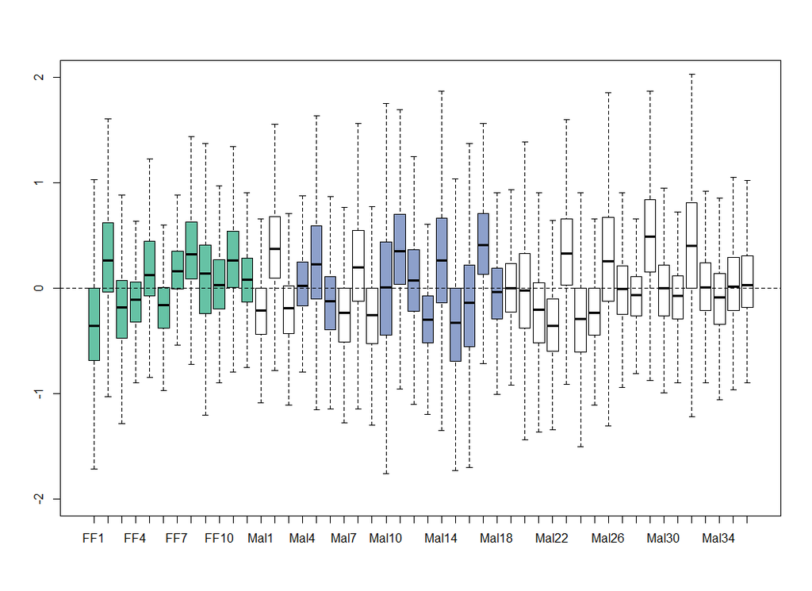

```r
plotRLE(set, outline =F, ylim=c(-2,2), col=colors[set$Group])
```

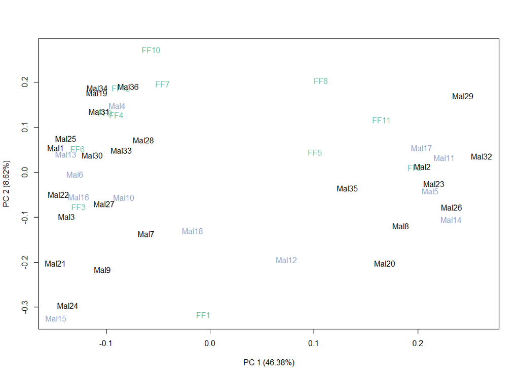

```r
plotPCA(set, col=colors[set$Group])
```

### 2.4.2 Upper quartile normalization

The upper quartile normalization [(UQ)](https://bmcbioinformatics.biomedcentral.com/articles/10.1186/1471-2105-11-94) normalizes the data accounting for the most highly expressed transcripts, since there is a bias on the number of reads associated to them, i.e, more expresssed trancripts generate more reads and futhermore the number of reads on these highly expressed genes is proportional to the total number of reads in the sample (if samples are in individual lanes or in the same lane), which is not the case for me. [Here](http://vinaykmittal.blogspot.com/2013/10/fpkmrpkm-normalization-caveat-and-upper.html)a more human explanation. And [here](https://academic.oup.com/bib/article/14/6/671/189645) a more recent paper on RNA data normalization.

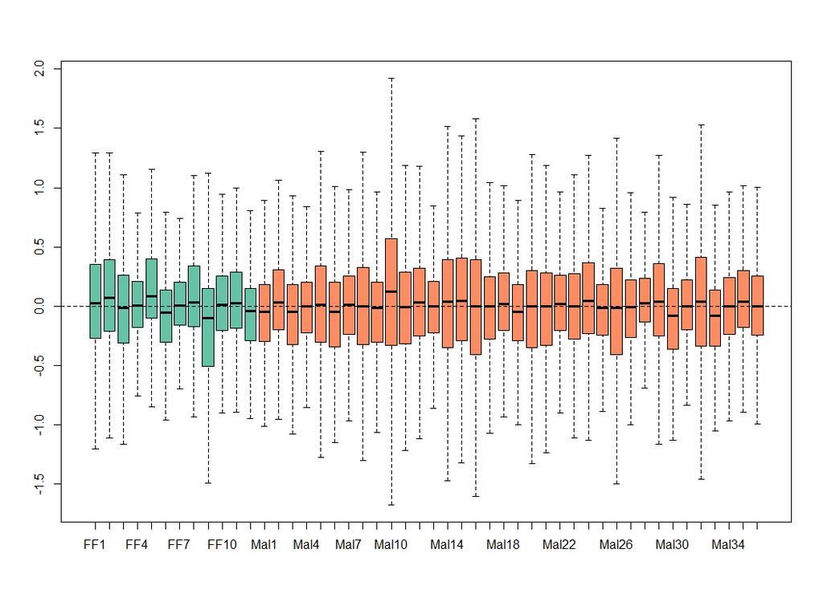

```r
set_n<-betweenLaneNormalization(set,which = "upper")
set_n$Diet<-factor(set_n$Diet)
plotRLE(set_n, outline=F, col=colors[set_n$Diet])
```

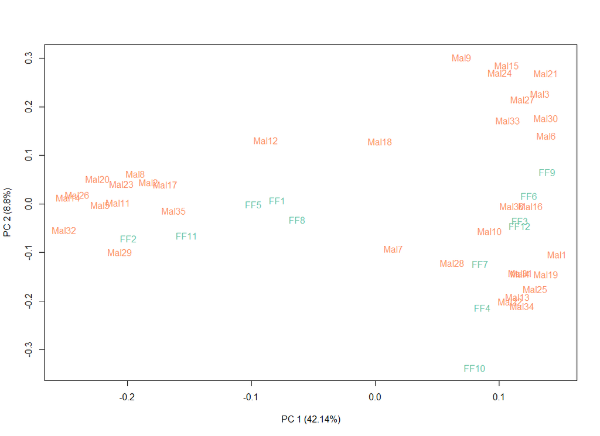

```r
plotPCA(set_n,col=colors[set_n$Diet])
```

### 2.4.3 Using empirical control genes

Since no spike in were used we will use the genes that have least changed between samples ( least significantly DE genes ) and use them as controls for the unwanted factors. So first we do a DE analysis and find the genes and then we do the normalization.

### 2.4.4 Empirical controls using the prior DE analisis using DESeq2

Now we are going to use the DESeq2 to do DE analysis so we can pick the least DE genes as controls.In this case I will estimate only one unwanted variacen variable.

```r
#Using RUVSeq
library(RUVSeq)
not.sig <- rownames(res)[which(res$pvalue > .2)]
empirical <- rownames(set_n)[ rownames(set_n) %in% not.sig ]
if("RDAVIDWebService" %in% (.packages())){
  detach("package:RDAVIDWebService", unload=TRUE)
}
set_n <- RUVg(set_n, empirical, k=1)
pData(set_n)
```

|  | Pig | Index | Group_sectio | Trial | Section | SectionTimeFed | TimeSectionFedChal | Collection | RNA_ext | Lib_const | Lane | Weight_3Week | RIN | Final_Weight | MLNT | Small_weight | Small_body_ratio | Bacteriodetes | wt_lt_ratio | z_score_animal | Litter | Conductance | Paracellular_permeability | Transcellular_permeability | Group | Diet | W_1 |
| --- | --- | --- | --- | --- | --- | --- | --- | --- | --- | --- | --- | --- | --- | --- | --- | --- | --- | --- | --- | --- | --- | --- | --- | --- | --- | --- | --- |
| FF1 | 33-12 | 3 | FFD | mhLZ | Duodenum | Duod_5FF | Wk5_Duod_FFNo | 6_17A | 4 | 8_25 | 2 | 9.0 | 7.7 | 16.6 | 75528.7009 | 1542 | 92.89157 | 0.023587493 | 0.2178478 | -0.9111080 | 33 | 6.760 | 183.2455 | -2.421892 | FF | FF | -0.086496825 |
| FF2 | 33-12 | 2 | FFI | mhLZ | Ileum | Ileum_5FF | Wk5_Il_FFNo | 6_17A | 16 | 8_29 | 7 | 9.0 | 8.9 | 16.6 | 75528.7009 | 1542 | 92.89157 | 0.005485464 | 0.2178478 | -0.9111080 | 33 | 6.760 | 183.2455 | -2.421892 | FF | FF | -0.211506670 |
| FF3 | 33-12 | 7 | FFJ | mhLZ | Jejunum | Jej_5FF | Wk5_Jej_FFNo | 6_17A | 10 | 8_27 | 2 | 9.0 | 7.5 | 16.6 | 75528.7009 | 1542 | 92.89157 | 0.010422381 | 0.2178478 | -0.9111080 | 33 | 6.760 | 183.2455 | -2.421892 | FF | FF | 0.121510026 |
| FF4 | 6-10 | 5 | FFD | mhLF | Duodenum | Duod_5FF | Wk5_Duod_FFNo | 4_3 | 5 | 8_25 | 5 | 10.5 | 8.8 | 17.1 | 451500.0000 | 1200 | 70.17544 | 0.006582556 | 0.2172808 | -0.9426755 | 6 | 6.690 | 668.5889 | 31.963960 | FF | FF | 0.078900028 |
| FF5 | 6-10 | 6 | FFI | mhLF | Ileum | Ileum_5FF | Wk5_Il_FFNo | 4_3 | 17 | 8_29 | 8 | 10.5 | 7.9 | 17.1 | 451500.0000 | 1200 | 70.17544 | 0.004388371 | 0.2172808 | -0.9426755 | 6 | 6.690 | 668.5889 | 31.963960 | FF | FF | -0.103399114 |
| FF6 | 6-10 | 1 | FFJ | mhLF | Jejunum | Jej_5FF | Wk5_Jej_FFNo | 4_3 | 11 | 8_27 | 5 | 10.5 | 9.2 | 17.1 | 451500.0000 | 1200 | 70.17544 | 0.004936917 | 0.2172808 | -0.9426755 | 6 | 6.690 | 668.5889 | 31.963960 | FF | FF | 0.116243083 |
| FF7 | 8-11 | 6 | FFD | mhLF | Duodenum | Duod_5FF | Wk5_Duod_FFNo | 4_3 | 6 | 8_25 | 6 | 13.1 | 8.5 | 19.9 | 18000.0000 | 1300 | 65.32663 | 0.014810752 | 0.2447724 | 0.5880298 | 8 | 6.689 | 392.7977 | 177.221600 | FF | FF | 0.078555574 |
| FF8 | 8-11 | 7 | FFI | mhLF | Ileum | Ileum_5FF | Wk5_Il_FFNo | 4_3 | 18 | 8_29 | 10 | 13.1 | 9.3 | 19.9 | 18000.0000 | 1300 | 65.32663 | 0.004936917 | 0.2447724 | 0.5880298 | 8 | 6.689 | 392.7977 | 177.221600 | FF | FF | -0.069702622 |
| FF9 | 8-11 | 2 | FFJ | mhLF | Jejunum | Jej_5FF | Wk5_Jej_FFNo | 4_3 | 12 | 8_27 | 6 | 13.1 | 9.3 | 19.9 | 18000.0000 | 1300 | 65.32663 | 0.009873834 | 0.2447724 | 0.5880298 | 8 | 6.689 | 392.7977 | 177.221600 | FF | FF | 0.136513085 |
| FF10 | 9-3 | 2 | FFD | mhLF | Duodenum | Duod_5FF | Wk5_Duod_FFNo | 4_4 | 6 | 8_25 | 1 | 14.1 | 9.1 | 22.2 | 31500.0000 | 1300 | 58.55856 | 0.004936917 | 0.2569444 | 1.2657538 | 9 | 5.177 | 177.4162 | 19.287990 | FF | FF | 0.073848987 |

[output cut: 38 more lines]

```r
ddsruv <- dds
ddsruv$W1 <- set_n$W_1
design(ddsruv) <- ~ W1 + Diet
dds<-ddsruv
```

## 2.5 Check sample distances

We will use the `dist` function to calculate Euclidean distances bewteen samples and see with the sample within groups are similar. And in this case we will use the rlog transformed data so the high variance if the low expressed genes do not influence the calculations.

Poisson distance rlog transformed data

The heatmap of the rlog transformed counts using poisson distance.

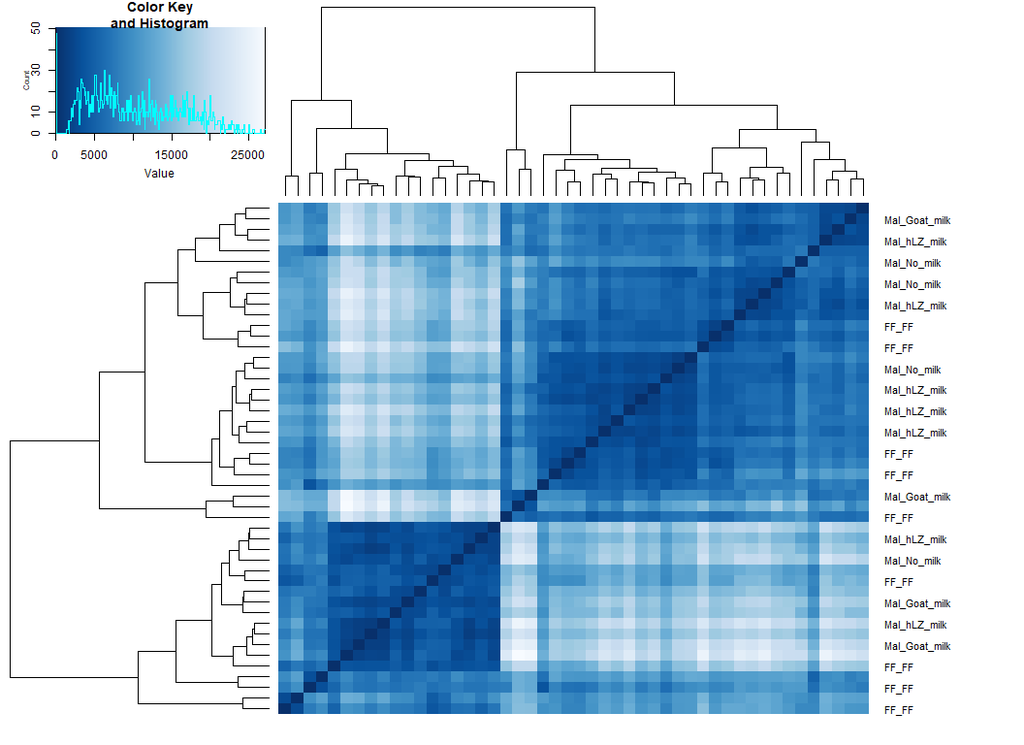

```r
colors<- colorRampPalette(rev(brewer.pal(9,"Blues")))(255)
hc<- hclust(poisd$dd)
heatmap.2(samplePoisDistMatrix, Rowv=as.dendrogram(hc), symm=T, trace="none", col= colors, margins=c(2,10), labCol=F)
```

We can also see the PCA plot:

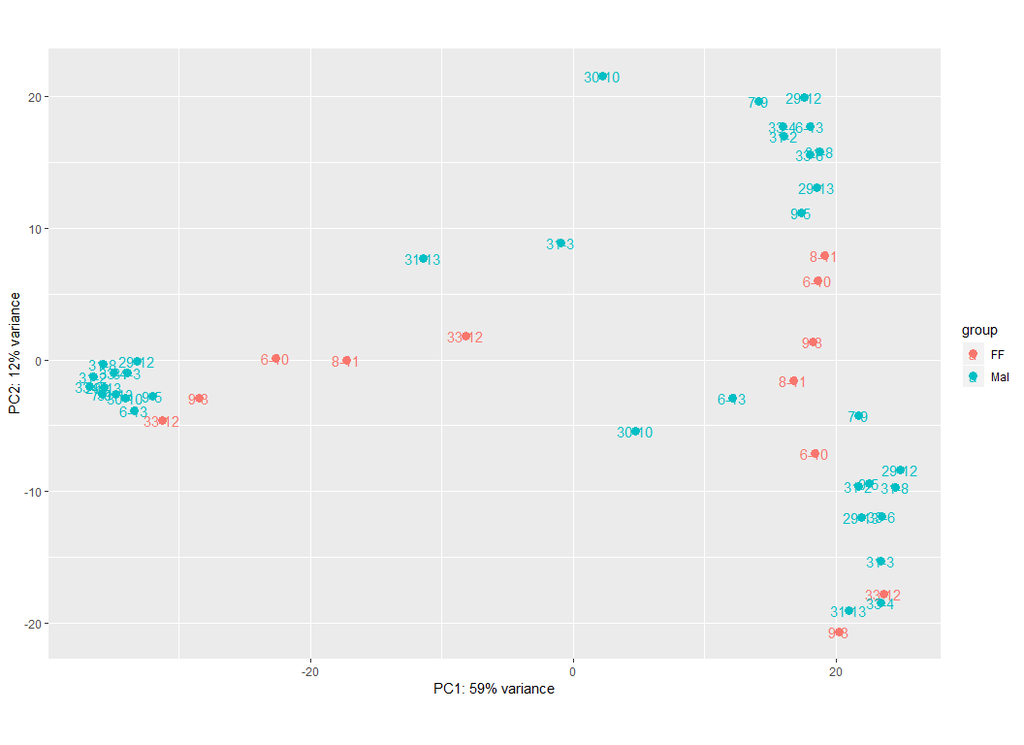

```r
library(ggplot2)
z <-plotPCA(rlogdds, intgroup = c( "Diet"))
z+ geom_text(aes(label = selectMetadata$Pig))
```

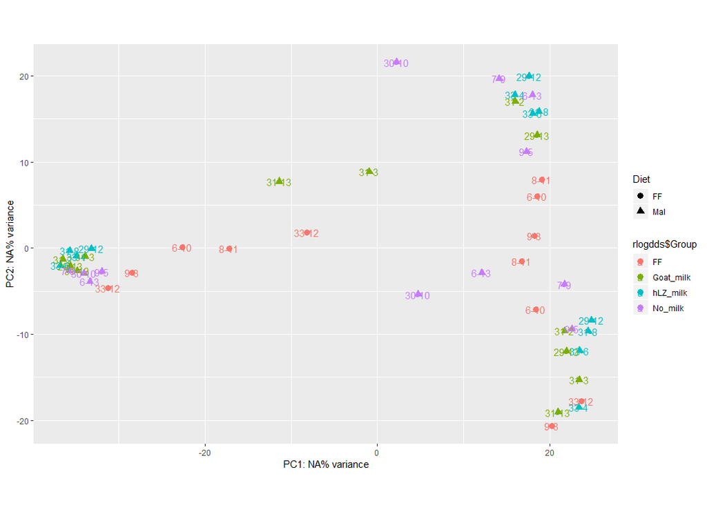

```r
# Using the both
percentVar <- round(100 * attr(z, "percentVar"))
ggplot(as.data.frame(z$data), aes(PC1, PC2, shape=Diet, color=rlogdds$Group)) +  geom_point(size=3) +
  xlab(paste0("PC1: ",percentVar[1],"% variance")) +
  ylab(paste0("PC2: ",percentVar[2],"% variance")) +
  coord_fixed()+ geom_text(aes(label = selectMetadata$Pig))
```

## 2.6 Differrential expression analaysis

It is convenient to make sure that FF is the first level in the Diet factor so the default log2 fold change can be calculatedmalnourished over full fed.

Now, we can run the DESeq function that will estimate the size factors (estimate for differences due to library size), estimate dispersion for each gene, and fit in a generalized linear model.

we have this number of genes with padj < 0.1 L2FC 1. the L2FC estimation is based on MLE (betaprior is False) and the last variable is the contrast that is used.

```r
summary(res)
```

out of 16980 with nonzero total read count adjusted p-value < 0.1 LFC > 0 (up) : 1044, 6.1% LFC < 0 (down) : 1342, 7.9% outliers [1] : 0, 0% low counts [2] : 0, 0% (mean count < 1) [1] see ‘cooksCutoff’ argument of ?results [2] see ‘independentFiltering’ argument of ?results

```r
#the low counts in the summary is the number of genes that were excluded from testing because the countes were lower than the mean count calculated by DESeq.
# it will test the last variable from the design ,
# This will give me the genes that are significantly different with a adj. pvalue < 0.1.
# To make it more stringent we can use adj.pvalue < 0.05, and L2fc > 2, or < -2.
```

Now we can filter the results by p. adjusted and log2foldChange values.Here we used padj< 0.1, log2FoldChange < -1 or log2FoldChange > 1. The table and the dimentions of the table of DE genes were:

```r
res.sort<- res[order(res$pvalue), ]
#head(res)
#Considering a padj < 0.1 being significant  we can subset the significant differentiated genes
res<-as.data.frame(res)
resSig_Salmon <- subset(res, padj< 0.1)
resSig_Salmon <- subset(resSig_Salmon, log2FoldChange < -1 | log2FoldChange > 1)
saveRDS(resSig_Salmon, file = file.path(output_dir,sprintf("FF_vs_Mal_all_Salmon_resSig_w_outlier.RDS")))
head(as.data.frame(resSig_Salmon))
```

|  | baseMean | log2FoldChange | lfcSE | stat | pvalue | padj |
| --- | --- | --- | --- | --- | --- | --- |
| ENSSSCG00000000061 | 659.341193 | 1.109129 | 0.2130183 | 5.206728 | 1.921990e-07 | 2.529875e-05 |
| ENSSSCG00000000298 | 1668.805131 | 1.236310 | 0.2375604 | 5.204191 | 1.948441e-07 | 2.535029e-05 |
| ENSSSCG00000000482 | 5.474637 | -2.470124 | 0.4680078 | -5.277956 | 1.306330e-07 | 1.863991e-05 |
| ENSSSCG00000000492 | 44752.754214 | -1.611905 | 0.3397156 | -4.744865 | 2.086458e-06 | 1.663289e-04 |
| ENSSSCG00000000679 | 12.798664 | 1.433332 | 0.4317091 | 3.320135 | 8.997395e-04 | 1.530819e-02 |
| ENSSSCG00000000718 | 3.229640 | -2.086806 | 0.7508513 | -2.779253 | 5.448405e-03 | 5.371949e-02 |

```r
dim(resSig_Salmon)
```

[1] 355 6

### 2.6.1 Increased strigency

Being more stringent we can see the number of genes with padj< 0.1 and L2FC < -1.5 or > 1.5

```r
resSig_Salmon<-resSig_Salmon[order(resSig_Salmon$padj), ]
resSig_Salmon1.5 <- subset(resSig_Salmon, log2FoldChange < -1.5 | log2FoldChange > 1.5)
dim(resSig_Salmon1.5)
```

[1] 140 6

### 2.6.2 Sorting by up regulated or down regulated genes

First a look at the top downregulated genes (based on log2foldchange):

```r
# sorting by the Log2FoldChange
head(as.data.frame(resSig_Salmon[order(resSig_Salmon$log2FoldChange), ])) # stronger downregulation
```

|  | baseMean | log2FoldChange | lfcSE | stat | pvalue | padj |
| --- | --- | --- | --- | --- | --- | --- |
| ENSSSCG00000038785 | 674.06445 | -30.000000 | 1.3155218 | -22.804640 | 4.123973e-115 | 7.002507e-111 |
| ENSSSCG00000039871 | 23.28095 | -30.000000 | 1.7033643 | -17.612204 | 1.985609e-69 | 1.685782e-65 |
| ENSSSCG00000017801 | 100.41094 | -4.181371 | 0.6615480 | -6.320586 | 2.605740e-10 | 8.675581e-08 |
| ENSSSCG00000039103 | 643.67266 | -4.168289 | 0.5198231 | -8.018669 | 1.068974e-15 | 1.210079e-12 |
| ENSSSCG00000029515 | 13.65720 | -4.096751 | 0.8319385 | -4.924343 | 8.464423e-07 | 8.356157e-05 |
| ENSSSCG00000001836 | 644.91384 | -4.000360 | 0.5398777 | -7.409754 | 1.265343e-13 | 1.074276e-10 |

```r
topdown_salmon<-rownames(head(resSig_Salmon[order(resSig_Salmon$log2FoldChange), ],10)) # stronger downregulation

#Getting the down regulated genes
downresSig_Salmon<-resSig_Salmon[resSig_Salmon$log2FoldChange < -1,]
downresSig_Salmon<-downresSig_Salmon[order(downresSig_Salmon$log2FoldChange),]
dim(downresSig_Salmon)
```

[1] 205 6

And now at the upregulated genes:

```r
head(as.data.frame(resSig_Salmon[order(-resSig_Salmon$log2FoldChange), ])) #stronger upregulation
```

|  | baseMean | log2FoldChange | lfcSE | stat | pvalue | padj |
| --- | --- | --- | --- | --- | --- | --- |
| ENSSSCG00000037571 | 408.983024 | 6.532259 | 1.1574564 | 5.643632 | 1.664993e-08 | 3.176582e-06 |
| ENSSSCG00000003086 | 12.552489 | 4.795659 | 0.8968846 | 5.347020 | 8.941429e-08 | 1.398409e-05 |
| ENSSSCG00000036961 | 8.318578 | 4.596479 | 1.0169598 | 4.519824 | 6.189115e-06 | 3.935999e-04 |
| ENSSSCG00000036649 | 303.293663 | 4.336747 | 0.8837746 | 4.907074 | 9.244505e-07 | 8.818635e-05 |
| ENSSSCG00000031227 | 6.322636 | 3.999223 | 1.4029589 | 2.850563 | 4.364184e-03 | 4.637287e-02 |
| ENSSSCG00000027851 | 30.545829 | 3.885471 | 1.4810020 | 2.623542 | 8.702075e-03 | 7.320885e-02 |

```r
topup_salmon<-rownames(head(resSig_Salmon[order(-resSig_Salmon$log2FoldChange), ],10)) #stronger upregulation

#Getting the up regulated genes
upresSig_Salmon<-resSig_Salmon[resSig_Salmon$log2FoldChange > 1,]
upresSig_Salmon<-upresSig_Salmon[order(-upresSig_Salmon$log2FoldChange),]
dim(upresSig_Salmon)
```

[1] 150 6

#### 2.6.2.1 List of genes with padj < 0.1, L2FC < -1 or > 1.

Now we can have the list of the genes that are DE expressed and down or up regulated and then convert the ensembl ids into gene names using BiomaRt.

```r
library(biomaRt)
mart<- useMart("ensembl")
Pig_ensembl<- useDataset("sscrofa_gene_ensembl", mart=mart)
Human<-useDataset("hsapiens_gene_ensembl", mart=mart)
down_genes_names<- getBM(attributes = c("ensembl_gene_id","external_gene_name"), filters= "ensembl_gene_id", values = rownames(downresSig_Salmon), mart = Pig_ensembl)
down_genes_names<-transform(merge(as.data.frame(downresSig_Salmon),down_genes_names,by.x=0, by.y ="ensembl_gene_id",all=TRUE), row.names=Row.names, Row.names=NULL)
down_genes_names_Salmon<- down_genes_names[order(down_genes_names$log2FoldChange),]
#The number of genes  we were able to find the gene name on BiomaRt
sum(down_genes_names_Salmon$external_gene_name != "")
```

[1] 147

```r
head(down_genes_names_Salmon[order(down_genes_names_Salmon$padj),], 30)
```

|  | baseMean | log2FoldChange | lfcSE | stat | pvalue | padj | external_gene_name |
| --- | --- | --- | --- | --- | --- | --- | --- |
| ENSSSCG00000038785 | 674.06445 | -30.000000 | 1.3155218 | -22.804640 | 4.123973e-115 | 7.002507e-111 | CA7 |
| ENSSSCG00000039871 | 23.28095 | -30.000000 | 1.7033643 | -17.612204 | 1.985609e-69 | 1.685782e-65 |  |
| ENSSSCG00000008959 | 198.15853 | -1.732380 | 0.1748497 | -9.907828 | 3.849238e-23 | 2.178669e-19 | CXCL2 |
| ENSSSCG00000004454 | 84.77586 | -2.570059 | 0.2699512 | -9.520458 | 1.724176e-21 | 7.319127e-18 | ME1 |
| ENSSSCG00000025020 | 50.60525 | -3.283190 | 0.3484590 | -9.422029 | 4.424551e-21 | 1.502578e-17 | PCSK9 |
| ENSSSCG00000033822 | 362.22304 | -3.365772 | 0.3871344 | -8.694066 | 3.496932e-18 | 5.937791e-15 | THRSP |
| ENSSSCG00000010554 | 2445.21600 | -2.063812 | 0.2444384 | -8.443073 | 3.091017e-17 | 4.373789e-14 | SCD |
| ENSSSCG00000040681 | 228.46014 | -3.035822 | 0.3640975 | -8.337938 | 7.559740e-17 | 9.168885e-14 | FABP4 |
| ENSSSCG00000039103 | 643.67266 | -4.168289 | 0.5198231 | -8.018669 | 1.068974e-15 | 1.210079e-12 | ADIPOQ |
| ENSSSCG00000010210 | 401.46686 | -2.948878 | 0.3768411 | -7.825257 | 5.066216e-15 | 5.376521e-12 | SLC16A9 |

[output cut: 20 more lines]

For the upregulated:

```r
up_genes_names<- getBM(attributes = c("ensembl_gene_id","external_gene_name"), filters= "ensembl_gene_id", values = rownames(upresSig_Salmon), mart = Pig_ensembl)
up_genes_names<-transform(merge(as.data.frame(upresSig_Salmon),up_genes_names,by.x=0, by.y ="ensembl_gene_id",all=TRUE), row.names=Row.names, Row.names=NULL)
up_genes_names_Salmon<- up_genes_names[order(up_genes_names$log2FoldChange),]
sum(up_genes_names_Salmon$external_gene_name != "")
```

[1] 104

```r
#The number of genes  we were able to find the gene name on BiomaRt
head(up_genes_names_Salmon[order(up_genes_names_Salmon$padj),],30)
```

|  | baseMean | log2FoldChange | lfcSE | stat | pvalue | padj | external_gene_name |
| --- | --- | --- | --- | --- | --- | --- | --- |
| ENSSSCG00000002009 | 6653.70142 | 1.270164 | 0.1371436 | 9.261564 | 2.014593e-20 | 5.701297e-17 | PCK2 |
| ENSSSCG00000007507 | 17001.31707 | 2.275387 | 0.2514747 | 9.048174 | 1.453790e-19 | 3.526478e-16 | PCK1 |
| ENSSSCG00000029592 | 611.76423 | 2.711659 | 0.3024851 | 8.964602 | 3.114036e-19 | 6.609541e-16 | GPRC5A |
| ENSSSCG00000035347 | 17777.28437 | 2.370102 | 0.2659688 | 8.911205 | 5.048093e-19 | 9.524069e-16 |  |
| ENSSSCG00000038221 | 2977.62967 | 1.417179 | 0.1687708 | 8.397059 | 4.578020e-17 | 5.979598e-14 | HSD17B2 |
| ENSSSCG00000011629 | 3214.52377 | 1.332366 | 0.1819556 | 7.322480 | 2.434293e-13 | 1.797143e-10 | ACAD11 |
| ENSSSCG00000014900 | 554.80826 | 1.165734 | 0.1608703 | 7.246422 | 4.279248e-13 | 3.027568e-10 | RAB30 |
| ENSSSCG00000023320 | 37399.62792 | 1.556535 | 0.2175457 | 7.154978 | 8.368653e-13 | 5.262953e-10 | CYP3A39 |
| ENSSSCG00000008211 | 51.71704 | 1.956902 | 0.2901353 | 6.744791 | 1.532469e-11 | 7.885252e-09 |  |
| ENSSSCG00000024029 | 239.03294 | 1.444186 | 0.2145795 | 6.730310 | 1.693020e-11 | 8.455140e-09 |  |

[output cut: 20 more lines]

I will use the list to annotate the total DE genes using the Biomart in Ensembl.And get the top 6 with lowest padjusted.

```r
#I will get the IDS and will use the following code
gene_names<- getBM(attributes = c("ensembl_gene_id","external_gene_name"), filters= "ensembl_gene_id", values = rownames(resSig_Salmon), mart = Pig_ensembl)
gene_names<-transform(merge(as.data.frame(resSig_Salmon),gene_names,by.x=0, by.y ="ensembl_gene_id",all=TRUE), row.names=Row.names, Row.names=NULL)
gene_names<-as.data.frame(gene_names[order(gene_names$padj),])
head(gene_names)
```

|  | baseMean | log2FoldChange | lfcSE | stat | pvalue | padj | external_gene_name |
| --- | --- | --- | --- | --- | --- | --- | --- |
| ENSSSCG00000038785 | 674.06445 | -30.000000 | 1.3155218 | -22.804640 | 4.123973e-115 | 7.002507e-111 | CA7 |
| ENSSSCG00000039871 | 23.28095 | -30.000000 | 1.7033643 | -17.612204 | 1.985609e-69 | 1.685782e-65 |  |
| ENSSSCG00000008959 | 198.15853 | -1.732380 | 0.1748497 | -9.907828 | 3.849238e-23 | 2.178669e-19 | CXCL2 |
| ENSSSCG00000004454 | 84.77586 | -2.570059 | 0.2699512 | -9.520458 | 1.724176e-21 | 7.319127e-18 | ME1 |
| ENSSSCG00000025020 | 50.60525 | -3.283190 | 0.3484590 | -9.422029 | 4.424551e-21 | 1.502578e-17 | PCSK9 |
| ENSSSCG00000002009 | 6653.70142 | 1.270164 | 0.1371436 | 9.261564 | 2.014593e-20 | 5.701297e-17 | PCK2 |

## 2.7 Diagnostic plots

To plot the counts of specific genes we can use the name of the gene or a a specific value related to it.

### 2.7.1 Volcano plot

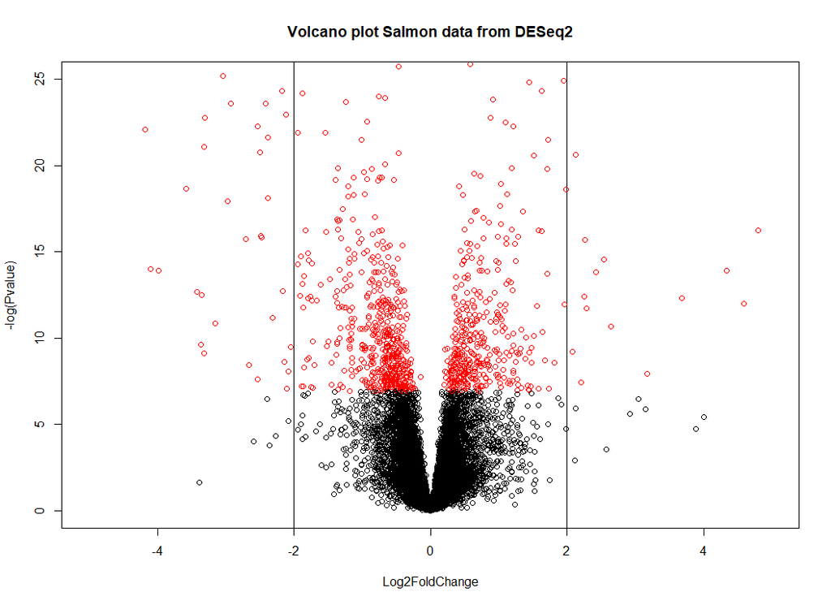

```r
# volcano plot
plot(res$log2FoldChange, -log(res$pvalue),main ="Volcano plot Salmon data from DESeq2", xlab= "Log2FoldChange", ylab = "-log(Pvalue)", pch = 21, col=ifelse(res$pvalue <0.001,"red","black"), xlim= c(-5,5), ylim =c(0,25), abline(v=c(-2,2)))
```

### 2.7.2 Plotting the gene with lowest p. adjusted

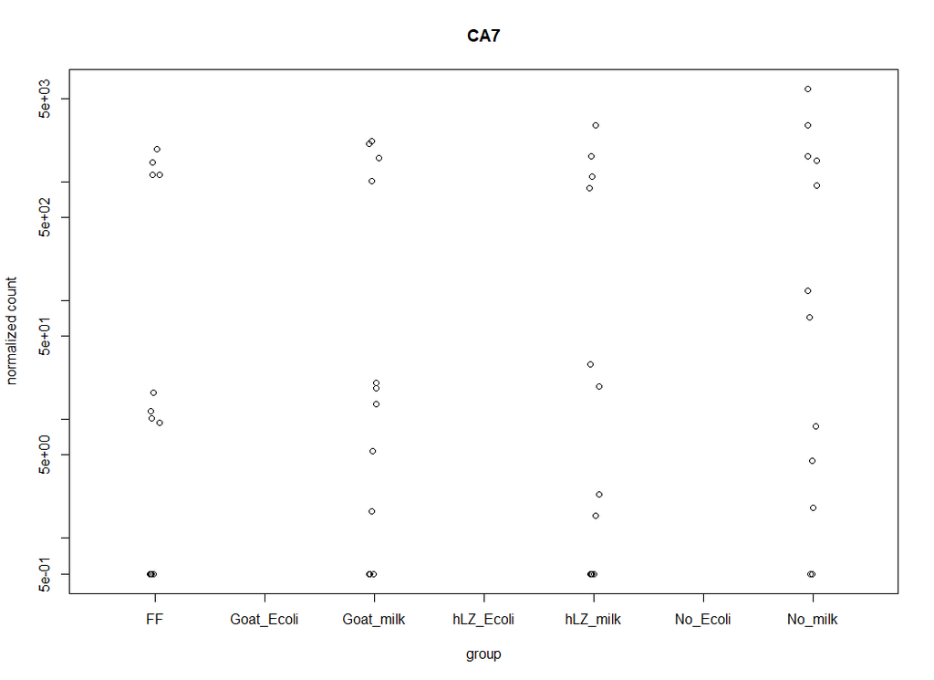

```r
# using the lower padj
topGene<- row.names(resSig_Salmon[which.min(resSig_Salmon$padj),])
plotCounts(dds,gene= topGene,main = gene_names$external_gene_name[1], intgroup="Group")
```

### 2.7.3 to do the MA plot:

[figure not shown]

```r
plotMA(res, ylim=c(-20,20))
```

### 2.7.4 To plot dispersion.(within group variability of each gene )

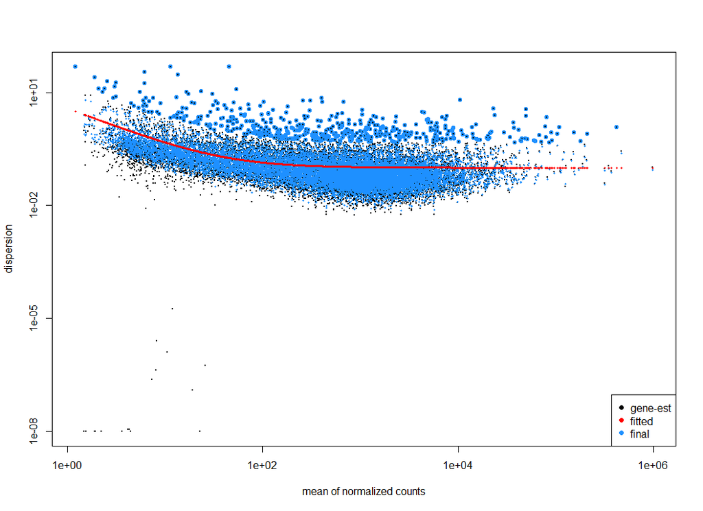

```r
plotDispEsts(dds)
```

### 2.7.5 histogram of pvalues

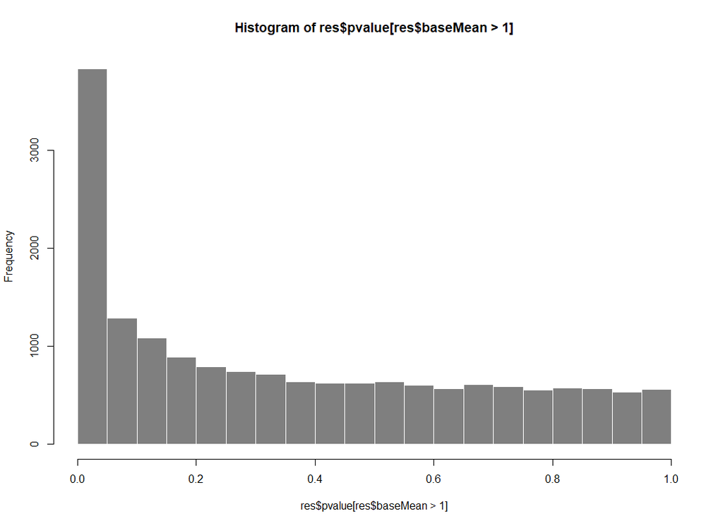

```r
hist(res$pvalue[res$baseMean>1], breaks=20, col="grey50", border="white")
```

### 2.7.6 Clustering

```r
library(genefilter)
```

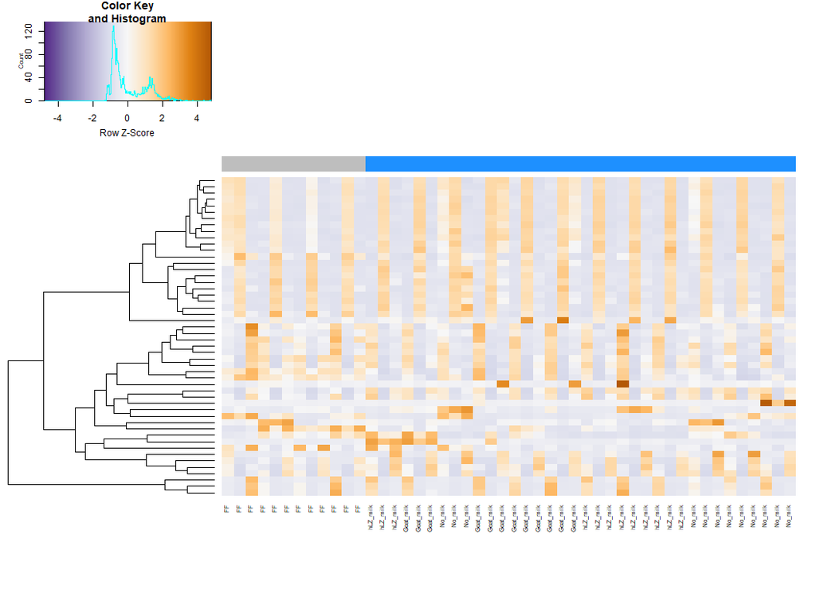

```r
#most hihgly variable genes
topVarGenes<- head(order(-rowVars(assay(rlogdds))),50)
colors<- colorRampPalette(rev(brewer.pal(9,"PuOr")))(255)
sidecols<- c("grey", "dodgerblue")[rlogdds$Diet]
mat<- assay(rlogdds)[topVarGenes,]
mat<- mat - rowMeans(mat)
colnames(mat)<- paste0(rlogdds$Group)
heatmap.2(mat,Colv=F, trace="none", col=colors, ColSideColors=sidecols, labRow=F, mar=c(10,2),scale="row")
```

### 2.7.7 Doing the clustering with normalized counts instead of rlog Counts

TPM of the 150 more variable DE genes(if DE genes < 150, all genes)

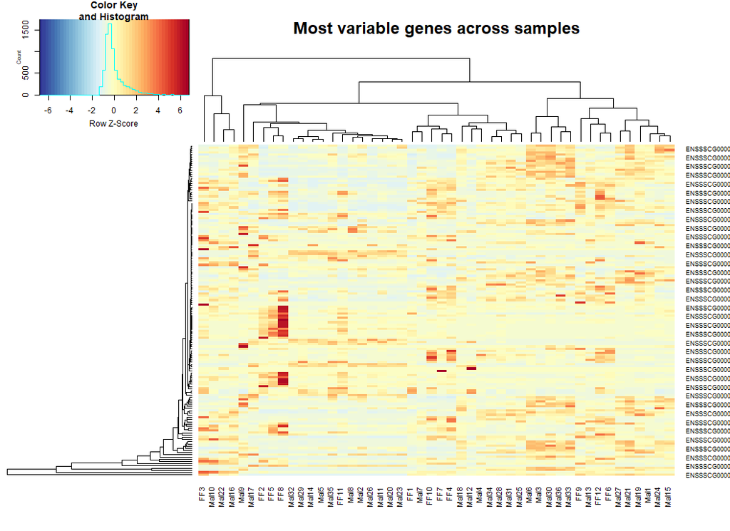

```r
# Prepare for the heatmap

# Get some nicer colours
mypalette <- brewer.pal(11,"RdYlBu")

morecols <- colorRampPalette(mypalette)

# Load library for heatmap
heatmap.2(highly_variable_norm_counts, col=rev(morecols(50)), trace="none",
              main="Most variable genes across samples", scale="row",
              labCol = labels)
```

```r
#To save the gene lists in both the cluster( 100 more variable genes in the resSig_Salmon2 table) and in the resSig_Salmon2 so I can used the transcripts to annotation and the other downstream application like panther or DAVID.
```

Cluster with all the DE genes using TPM

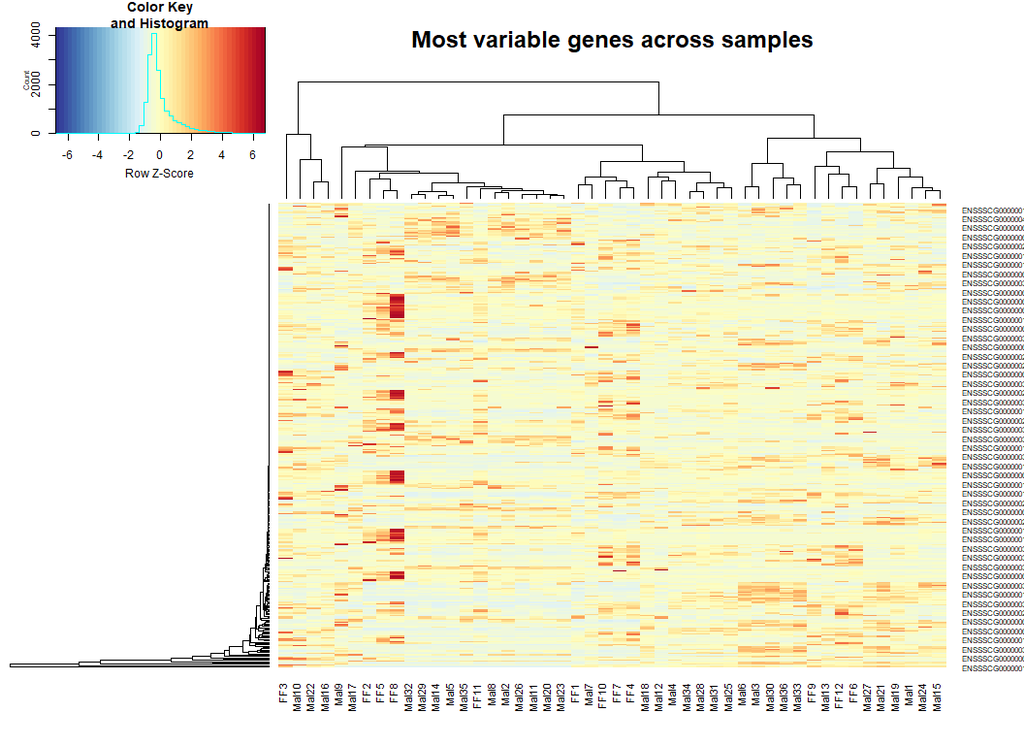

```r
DE_counts<- tpmDE
heatmap.2(DE_counts, col=rev(morecols(50)), trace="none",
              main="Most variable genes across samples", scale="row",
              labCol = labels)
```